# Part I - Ford Go Bike Data Exploration

## Introduction

Ford GoBike is a publicly available dataset that includes information about individual rides made in a bike-sharing system covering the greater San Francisco Bay area. The dataset can be downloaded from [here](https://video.udacity-data.com/topher/2020/October/5f91cf38_201902-fordgobike-tripdata/201902-fordgobike-tripdata.csv)

The data contains the following information(columns) for each individual ride:

- duration_sec - this is trip duration in seconds
- start_time- Start Time and Date for the trip
- end_time -End Time and Date for the trip
- start_station_id - Start Station ID
- start_station_name - Start Station Name
- start_station_latitude - Start Station Latitude
- start_station_longitude - Start Station Longitude
- end_station_id - End Station ID
- end_station_name - End Station Name
- end_station_latitude - End Station Latitude
- end_station_longitude - End Station Longitude
- bike_id - Bike ID
- user_type- (Subscriber or Customer — “Subscriber” = Member or “Customer” = Casual)
- member_birth_year - Member Year of Birth
- member_gender - Member Gender
- bike_share_for_all_trip - boolean value with yes and no values

## Preliminary Wrangling

```python
# import all packages and set plots to be embedded inline
import numpy as np
import pandas as pd
import matplotlib.pyplot as plt
import seaborn as sb

%matplotlib inline
```

### Load the dataset

```python
# load the dataset into a dataframe
df = pd.read_csv('201902-fordgobike-tripdata.csv',parse_dates=True)
```

```python
# getting the structure of the dataset
df.head()
```

|  | duration_sec | start_time | end_time | start_station_id | start_station_name | start_station_latitude | start_station_longitude | end_station_id | end_station_name | end_station_latitude | end_station_longitude | bike_id | user_type | member_birth_year | member_gender | bike_share_for_all_trip |
| --- | --- | --- | --- | --- | --- | --- | --- | --- | --- | --- | --- | --- | --- | --- | --- | --- |
| 0 | 52185 | 2019-02-28 17:32:10.1450 | 2019-03-01 08:01:55.9750 | 21.0 | Montgomery St BART Station (Market St at 2nd St) | 37.789625 | -122.400811 | 13.0 | Commercial St at Montgomery St | 37.794231 | -122.402923 | 4902 | Customer | 1984.0 | Male | No |
| 1 | 42521 | 2019-02-28 18:53:21.7890 | 2019-03-01 06:42:03.0560 | 23.0 | The Embarcadero at Steuart St | 37.791464 | -122.391034 | 81.0 | Berry St at 4th St | 37.775880 | -122.393170 | 2535 | Customer | NaN | NaN | No |
| 2 | 61854 | 2019-02-28 12:13:13.2180 | 2019-03-01 05:24:08.1460 | 86.0 | Market St at Dolores St | 37.769305 | -122.426826 | 3.0 | Powell St BART Station (Market St at 4th St) | 37.786375 | -122.404904 | 5905 | Customer | 1972.0 | Male | No |
| 3 | 36490 | 2019-02-28 17:54:26.0100 | 2019-03-01 04:02:36.8420 | 375.0 | Grove St at Masonic Ave | 37.774836 | -122.446546 | 70.0 | Central Ave at Fell St | 37.773311 | -122.444293 | 6638 | Subscriber | 1989.0 | Other | No |
| 4 | 1585 | 2019-02-28 23:54:18.5490 | 2019-03-01 00:20:44.0740 | 7.0 | Frank H Ogawa Plaza | 37.804562 | -122.271738 | 222.0 | 10th Ave at E 15th St | 37.792714 | -122.248780 | 4898 | Subscriber | 1974.0 | Male | Yes |

```python
# column information including datatypes and non-null values
df.info()
```

```
<class 'pandas.core.frame.DataFrame'>
RangeIndex: 183412 entries, 0 to 183411
Data columns (total 16 columns):
duration_sec               183412 non-null int64
start_time                 183412 non-null object
end_time                   183412 non-null object
start_station_id           183215 non-null float64
start_station_name         183215 non-null object
start_station_latitude     183412 non-null float64
start_station_longitude    183412 non-null float64
end_station_id             183215 non-null float64
end_station_name           183215 non-null object
end_station_latitude       183412 non-null float64
end_station_longitude      183412 non-null float64
bike_id                    183412 non-null int64
user_type                  183412 non-null object
member_birth_year          175147 non-null float64
member_gender              175147 non-null object
bike_share_for_all_trip    183412 non-null object
dtypes: float64(7), int64(2), object(7)
memory usage: 22.4+ MB
```

```python
#check for unique values
print(df.nunique())
```

```
duration_sec                 4752
start_time                 183401
end_time                   183397
start_station_id              329
start_station_name            329
start_station_latitude        334
start_station_longitude       335
end_station_id                329
end_station_name              329
end_station_latitude          335
end_station_longitude         335
bike_id                      4646
user_type                       2
member_birth_year              75
member_gender                   3
bike_share_for_all_trip         2
dtype: int64
```

```python
#check for null values
df.isna().sum()
```

```
duration_sec                  0
start_time                    0
end_time                      0
start_station_id            197
start_station_name          197
start_station_latitude        0
start_station_longitude       0
end_station_id              197
end_station_name            197
end_station_latitude          0
end_station_longitude         0
bike_id                       0
user_type                     0
member_birth_year          8265
member_gender              8265
bike_share_for_all_trip       0
dtype: int64
```

```python
# check the percentage of null values
df.isnull().sum()/df.shape[0]*100
```

```
duration_sec               0.000000
start_time                 0.000000
end_time                   0.000000
start_station_id           0.107408
start_station_name         0.107408
start_station_latitude     0.000000
start_station_longitude    0.000000
end_station_id             0.107408
end_station_name           0.107408
end_station_latitude       0.000000
end_station_longitude      0.000000
bike_id                    0.000000
user_type                  0.000000
member_birth_year          4.506248
member_gender              4.506248
bike_share_for_all_trip    0.000000
dtype: float64
```

```python
#check for duplicates
df.duplicated().sum()
```

```
0
```

## Data cleaning

Here we will address the following data quality and tidiness issues that we have encountered so far;

- there are missing values in station information columns
- change datatype of the following columns
  - start_time and end_time datatype need to be changed to datetime
  - convert bike_id datatype to string
  - Convert the start_station_id and end_station_id to int64
  - convert member_birth_year to int64

### Issue #1 : Missing values

- Define: Drop the missing Values

Code:

```python
#create a copy of the dataframe
bike_df = df.copy()
```

```python
#Calculate age from the member birth year as at 2019
bike_df['member_age'] = 2019-bike_df['member_birth_year']
```

```python
#drop missing values
bike_df.dropna(inplace=True)
```

Test

```python
bike_df.isnull().any().sum()
```

```
0
```

### Issue #2 : Change datatypes

Define - Convert the datatypes to the appropriate ones for the following columns

- start_time
- end_time
- bike_id
- start_station_id
- end_station_id
- member_birth_year
- member_age

Code

```python
#change date columns to datetime
bike_df['start_time'] = pd.to_datetime(bike_df['start_time'])
bike_df['end_time'] = pd.to_datetime(bike_df['end_time'])
#change bike_id datatype to string
bike_df['bike_id'] =bike_df.bike_id.astype(str)
#Covert station id to int
bike_df['start_station_id'] = bike_df.start_station_id.astype('int64')
bike_df['end_station_id'] = bike_df.end_station_id.astype('int64')
#convert member_birth_year to integer
bike_df['member_birth_year'] = bike_df.member_birth_year.astype('int64')
#convert the age to int

bike_df['member_age'] = bike_df.member_age.astype(int)
```

Test

```python
print(bike_df.info())
```

```
<class 'pandas.core.frame.DataFrame'>
Int64Index: 174952 entries, 0 to 183411
Data columns (total 17 columns):
duration_sec               174952 non-null int64
start_time                 174952 non-null datetime64[ns]
end_time                   174952 non-null datetime64[ns]
start_station_id           174952 non-null int64
start_station_name         174952 non-null object
start_station_latitude     174952 non-null float64
start_station_longitude    174952 non-null float64
end_station_id             174952 non-null int64
end_station_name           174952 non-null object
end_station_latitude       174952 non-null float64
end_station_longitude      174952 non-null float64
bike_id                    174952 non-null object
user_type                  174952 non-null object
member_birth_year          174952 non-null int64
member_gender              174952 non-null object
bike_share_for_all_trip    174952 non-null object
member_age                 174952 non-null int64
dtypes: datetime64[ns](2), float64(4), int64(5), object(6)
memory usage: 24.0+ MB
None
```

```python
type(bike_df['bike_id'][0])
```

```
str
```

```python
type(bike_df['start_time'][0])
```

```
pandas._libs.tslibs.timestamps.Timestamp
```

### Dataset Structure

The dataset is a dataframe with features of indivual ride in the columns and each row is a trip ride. There are 183412 fordgobike trips in the dataset with the following 16 features: duration_sec, start_time, end_time, start_station_id, start_station_name, start_station_latitude, start_station_longitude, end_station_id, end_station_name, end_station_latitude ,end_station_longitude, bike_id, user_type, member_birth_year, member_gender, bike_share_for_all_trip.

### The main feature(s) of interest in the dataset are:

- duration_sec - this is trip duration in seconds
- start_time- Start Time and Date for the trip
- end_time -End Time and Date for the trip
- start_station_name - Start Station Name
- end_station_name - End Station Name
- user_type- (Subscriber or Customer — “Subscriber” = Member or “Customer” = Casual)
- member_birth_year - Member Year of Birth
- member_gender - Member Gender

In the above features am interested in understanding how the trip duration is related to them.

### The following features in the dataset will help support my investigation into feature(s) of interest

- Trip duration relies mostly on the start stations and end stations.
- User_type, birthyear and gender also effect trip duration.

## Univariate Exploration

### Question 1: What is the average trip ride duration?

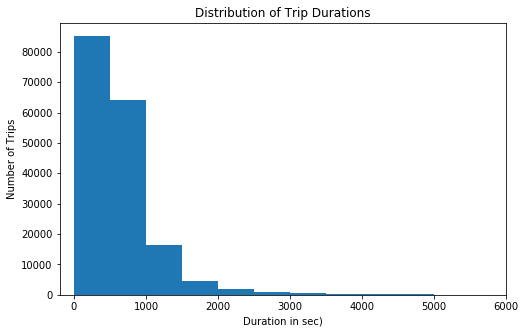

```python
binsize = 500
bins = np.arange(0, bike_df['duration_sec'].max()+binsize, binsize)

plt.figure(figsize=[8, 5])
plt.hist(data = bike_df, x = 'duration_sec', bins = bins)
plt.title('Distribution of Trip Durations')
plt.xlabel('Duration in sec)')
plt.ylabel('Number of Trips')
plt.xlim([-200, 6000])
plt.show();
```

There distribution is skewed to the right so lets put it on log scale.

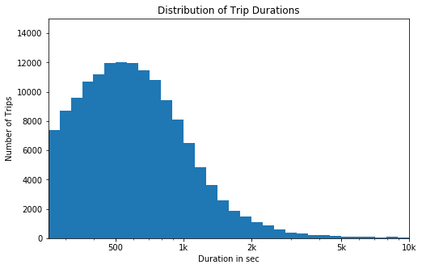

```python
log_binsize = 0.05
log_bins = 10 ** np.arange(2.4, np.log10(df['duration_sec'].max()) + log_binsize, log_binsize)

plt.figure(figsize=[8, 5])
plt.hist(data = bike_df, x = 'duration_sec', bins = log_bins)
plt.title('Distribution of Trip Durations')
plt.xlabel('Duration in sec')
plt.ylabel('Number of Trips')
plt.xscale('log')
plt.xticks([500, 1e3, 2e3, 5e3, 1e4], [500, '1k', '2k', '5k', '10k'])
plt.axis([0, 10000, 0, 15000])
plt.show();
```

### Question 2: What is the age of users who mostly participate in the bike rides?

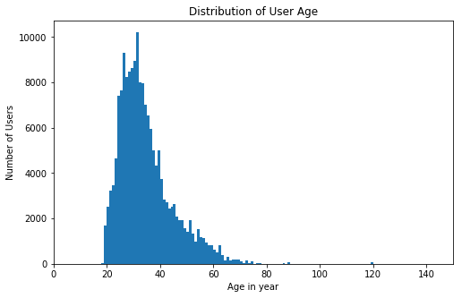

```python
# Plotting age distribution derived from member's birth year.
binsize = 1
bins = np.arange(0, bike_df['member_age'].max()+binsize, binsize)
plt.figure(figsize=[8, 5])
plt.hist(data = bike_df.dropna(), x = 'member_age', bins = bins)
plt.title('Distribution of User Age')
plt.xlabel('Age in year')
plt.ylabel('Number of Users')
plt.xlim([0,150])
plt.show()
```

The distribution is more concentrated between 20 to 60 years old. **The age seems to have outliers**. I will use a box plot to verify and then remove them.

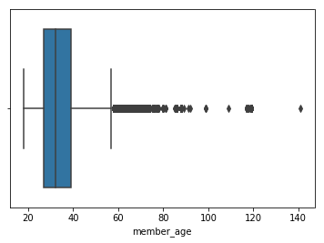

```python
#Box plot to check outliers in the age variable
#First, let us explore the age in the dataset
sb.boxplot(data=bike_df.dropna(), x='member_age');
```

```python
#remove any records with age value above 52
bike_df = bike_df.query('member_age<52')
```

```python
bike_df['member_age'] = bike_df['member_age'].astype(int)
```

```python
bike_df.info()
```

```
<class 'pandas.core.frame.DataFrame'>
Int64Index: 162026 entries, 0 to 183411
Data columns (total 17 columns):
duration_sec               162026 non-null int64
start_time                 162026 non-null datetime64[ns]
end_time                   162026 non-null datetime64[ns]
start_station_id           162026 non-null int64
start_station_name         162026 non-null object
start_station_latitude     162026 non-null float64
start_station_longitude    162026 non-null float64
end_station_id             162026 non-null int64
end_station_name           162026 non-null object
end_station_latitude       162026 non-null float64
end_station_longitude      162026 non-null float64
bike_id                    162026 non-null object
user_type                  162026 non-null object
member_birth_year          162026 non-null int64
member_gender              162026 non-null object
bike_share_for_all_trip    162026 non-null object
member_age                 162026 non-null int64
dtypes: datetime64[ns](2), float64(4), int64(5), object(6)
memory usage: 22.3+ MB
```

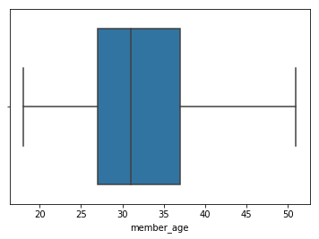

```python
#test if the outliers are removed
sb.boxplot(data=bike_df, x='member_age')
```

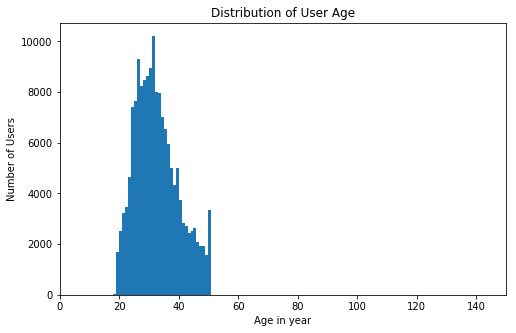

```python
# Plotting age distribution derived from member's birth year.
binsize = 1
bins = np.arange(0, bike_df['member_age'].max()+binsize, binsize)
plt.figure(figsize=[8, 5])
plt.hist(data = bike_df.dropna(), x = 'member_age', bins = bins)
plt.title('Distribution of User Age')
plt.xlabel('Age in year')
plt.ylabel('Number of Users')
plt.xlim([0,150])
plt.show()
```

The distribution is more concentrated between 20 to 55 years old.

### Question 3: Which user_type make most trip rides?

```python
# create a function for a count plot
def count_plot(x):
    default_color = sb.color_palette()[0]
    sb.countplot( x = x, color = default_color)
    plt.ylabel('count')
    plt.show()
```

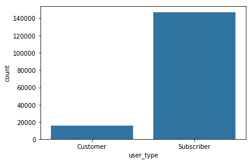

```python
# plot a bar of user_type
count_plot(bike_df['user_type'])
```

Subscribers do the most bike rides

### Question 4: Which gender does more bike rides?

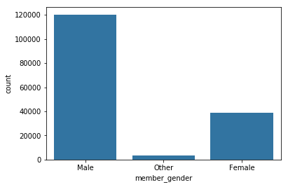

```python
# plot a bar of the number of rides per member_gender
member_gender = bike_df['member_gender'].dropna()
count_plot(member_gender)
```

The number of rides done by the male gender tripples that of females.

### Question 5: How many rides had bike sharing done?

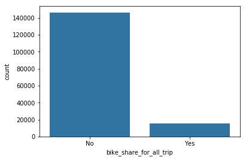

```python
bike_share_for_all_trip = bike_df['bike_share_for_all_trip'].dropna()
count_plot(bike_share_for_all_trip)
```

There was no bike sharing in most of the trip rides

### Question 6: How are rides distributed in the stations?

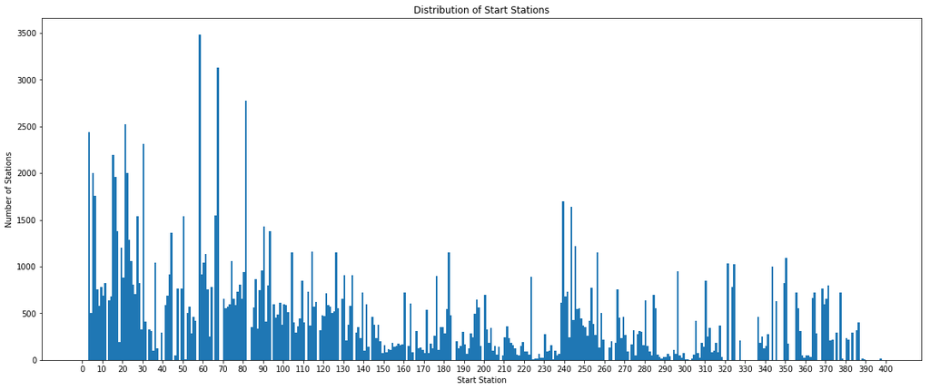

```python
# a function to plot distribution.
binsize = 1
bins = np.arange(0, bike_df['start_station_id'].max()+binsize, binsize)

plt.figure(figsize=[20, 8])
plt.xticks(range(0, 401, 10))
plt.hist(data = bike_df.dropna(), x = 'start_station_id', bins = bins)
plt.title('Distribution of Start Stations')
plt.xlabel('Start Station')
plt.ylabel('Number of Stations')
plt.show()
```

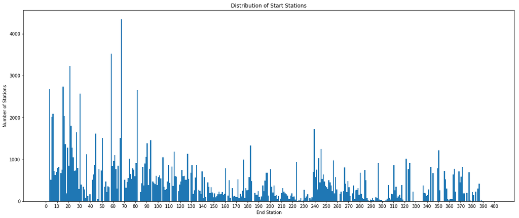

```python
binsize = 1
bins = np.arange(0, bike_df['end_station_id'].max()+binsize, binsize)

plt.figure(figsize=[20, 8])
plt.xticks(range(0, 401, 10))
plt.hist(data = bike_df.dropna(), x = 'end_station_id', bins = bins)
plt.title('Distribution of Start Stations')
plt.xlabel('End Station')
plt.ylabel('Number of Stations')
plt.show()
```

Same stations are more frequent as start stations and end stations.

### Question 7: What is the daily bike ride?

```python
# new columns from start_time
bike_df['start_month'] = bike_df.start_time.dt.month
bike_df['start_weekday'] = bike_df.start_time.dt.weekday
bike_df['start_hour'] = bike_df.start_time.dt.hour
#new columns from end_time
bike_df['end_month'] = bike_df.end_time.dt.month
bike_df['end_weekday'] = bike_df.end_time.dt.weekday
bike_df['end_hour'] = bike_df.end_time.dt.hour

# convert seconds to minutes
bike_df['duration_minutes'] = bike_df['duration_sec']/60
```

```python
# labels to use in plots
month_labels = ['Jan', 'Feb', 'Mar', 'Apr', 'May', 'Jun', 'Jul', 'Aug', 'Sep', 'Oct', 'Nov', 'Dec']
weekday_labels = ['Mon', 'Tue', 'Wed', 'Thu', 'Fri', 'Sat', 'Sun']
```

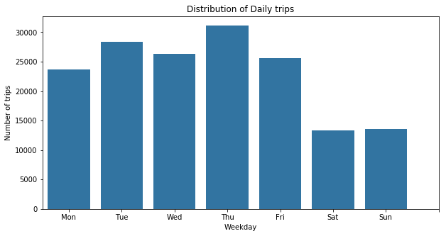

```python
# plot a countplot
plt.figure(figsize=[10,5])
sb.countplot(data = bike_df, x = 'start_weekday', color = sb.color_palette()[0])
plt.xlabel('start_weekday')
plt.title('Distribution of Daily trips')
plt.xticks(np.arange(0, 7 + 1, 1),weekday_labels)
plt.xlabel('Weekday')
plt.ylabel('Number of trips')
plt.show()
```

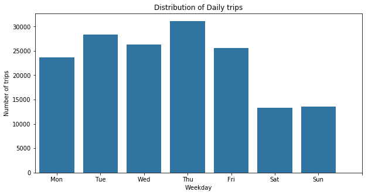

```python
# plot a countplot
plt.figure(figsize=[10,5])
sb.countplot(data = bike_df, x = 'end_weekday', color = sb.color_palette()[0])
plt.xlabel('end_weekday')
plt.title('Distribution of Daily trips')
plt.xticks(np.arange(0, 7 + 1, 1),weekday_labels)
plt.xlabel('Weekday')
plt.ylabel('Number of trips')
plt.show()
```

### Question 8: Which hours do people prefer for rides?

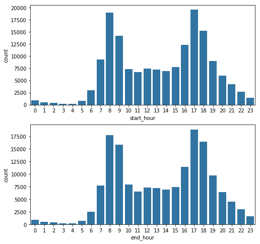

```python
# ride frequency per hours

fig, ax = plt.subplots(2,figsize = [8,8])
default_color = sb.color_palette()[0]
sb.countplot(data = bike_df, x = 'start_hour', color = default_color,  ax = ax[0])
sb.countplot(data = bike_df, x = 'end_hour', color = default_color, ax = ax[1])
```

Most trip rides are done in the 8th, 9th, 17th and 18th hours. This may imply that most rides are done in the evening and in the morning.

### Question 9: Which month had the highest rides?

```
['162013 (99.992%)', '13 (0.008%)']
```

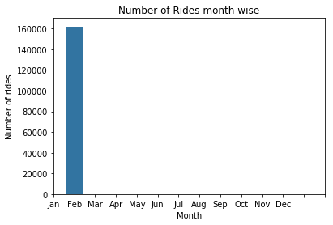

```python
# trip end frequency per month

sb.countplot(x=bike_df['end_month'],
                   order=bike_df['end_month'].value_counts(ascending=False).index)
plt.xticks(np.arange(-1, 12 + 1, 1),month_labels)
plt.xlabel('end_month')
plt.title('Number of Rides month wise')
plt.xlabel('Month')
plt.ylabel('Number of rides')

abs_values = bike_df['end_month'].value_counts(ascending=False)
rel_values = bike_df['end_month'].value_counts(ascending=False, normalize=True).values * 100
lbls = [f'{p[0]} ({p[1]:.3f}%)' for p in zip(abs_values, rel_values)]
lbls
```

```
['162026 (100.000%)']
```

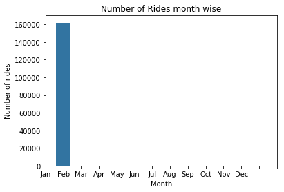

```python
# trip end frequency per month

sb.countplot(x=bike_df['start_month'],
                   order=bike_df['start_month'].value_counts(ascending=False).index)
plt.xticks(np.arange(-1, 12 + 1, 1),month_labels)
plt.xlabel('start_month')
plt.title('Number of Rides month wise')
plt.xlabel('Month')
plt.ylabel('Number of rides')

abs_values = bike_df['start_month'].value_counts(ascending=False)
rel_values = bike_df['start_month'].value_counts(ascending=False, normalize=True).values * 100
lbls = [f'{p[0]} ({p[1]:.3f}%)' for p in zip(abs_values, rel_values)]
lbls
```

## Bivariate Exploration

### Question 1: How is trip duration related to age?

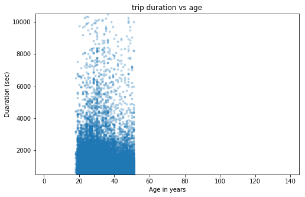

```python
plt.figure(figsize=[8,5])
plt.scatter((2019 - bike_df['member_birth_year']), bike_df['duration_sec'], alpha = 0.25, marker = '.' )
plt.axis([-5, 145, 500, 10500])
plt.xlabel('Age in years')
plt.ylabel('Duaration (sec)')
plt.title('trip duration vs age')
plt.show()
```

Most of the durations are below 4000 and age is below 60.

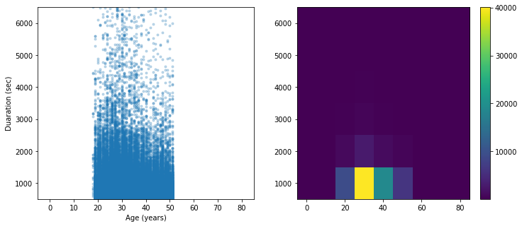

```python
plt.figure(figsize=[12,5])

plt.subplot(1, 2, 1)
plt.scatter((bike_df['member_age']), bike_df['duration_sec'], alpha = 0.25, marker = '.' )
plt.axis([-5, 85, 500, 6500])
plt.xlabel('Age (years)')
plt.ylabel('Duaration (sec)')

plt.subplot(1, 2, 2)
bins_y = np.arange(500, 6500+1, 1000)
bins_x = np.arange(-5, 85+1, 10)
plt.hist2d(( bike_df['member_age']), bike_df['duration_sec'],
           bins = [bins_x, bins_y])
plt.colorbar(ticks=[10000, 20000, 30000, 40000]);
plt.show()
```

Higher duration is done by younger members between 20 and 50.

### Question 2: How is trip duration depended on on gender, bike share for all trip and on member type?

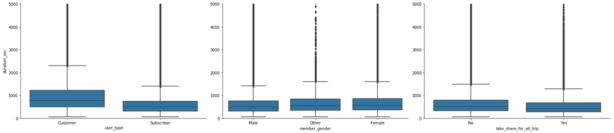

```python
#create a box plots for user_type, member_gender, bike_share_for_all_trip

def boxgrid(x, y, **kwargs):
    #creating box plots with seaborn's PairGrid
    default_color = sb.color_palette()[0]
    sb.boxplot(x, y, color = default_color)

plt.figure(figsize = [10, 10])
g = sb.PairGrid(data = bike_df, y_vars = 'duration_sec', x_vars = ['user_type', 'member_gender',
                                                                         'bike_share_for_all_trip'],
                size = 5, aspect = 1.5)
g.map(boxgrid)
plt.ylim([0,5000])
plt.show();
```

Customers spend more time on average compare to subscribers while the female gender spend more time on average than male.

Bike share for all trip tends to be similar on average across all types .

### Question 3: How is user type related to other variables?

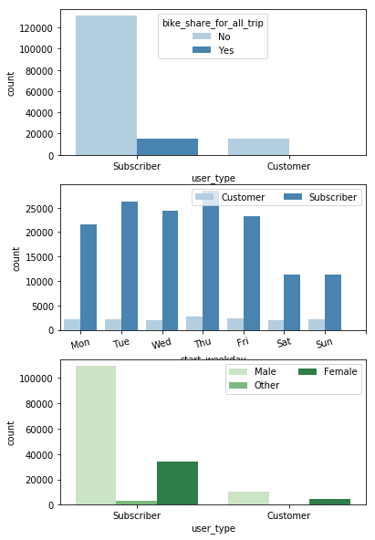

```python
plt.figure(figsize = [6, 10])

#user_type vs bike_share_for_all_trip
plt.subplot(3, 1, 1)
sb.countplot(data = bike_df, x = 'user_type', hue = 'bike_share_for_all_trip', order=bike_df.user_type.value_counts().index,
             palette = 'Blues')

#end_day vs. user_type
ax = plt.subplot(3, 1, 2)
sb.countplot(data = bike_df, x = 'start_weekday', hue = 'user_type', palette = 'Blues')
plt.xticks(np.arange(0, 7 + 1, 1),weekday_labels)
ax.legend(ncol = 2)
plt.xticks(rotation=15)

# subplot 3: user_type vs. member_gender,
ax = plt.subplot(3, 1, 3)
sb.countplot(data = bike_df, x = 'user_type', hue = 'member_gender',order=bike_df.user_type.value_counts().index,
             palette = 'Greens')
ax.legend(loc = 1, ncol = 2)
plt.show()
```

User type does not affect the number of trips in a weekday. Bike sharing is only available for subscribers. Subscribers who are male do most of the trips.

## Multivariate Exploration

### Question 1: How does gender and user type affect trip duration?

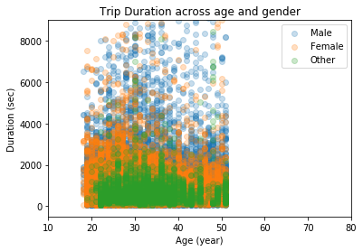

```python
gender_markers = [['Male', 'M'],['Female', 'F'],['Other', 'O']]

for gender, marker in gender_markers:
    df_gender = bike_df[bike_df['member_gender'] == gender]
    plt.scatter((df_gender['member_age']), df_gender['duration_sec'],  alpha=0.25)
plt.legend(['Male','Female','Other'])
plt.axis([10, 80, -500, 9000 ])
plt.xlabel('Age (year)')
plt.title('Trip Duration across age and gender')
plt.ylabel('Duration (sec)')
plt.show()
```

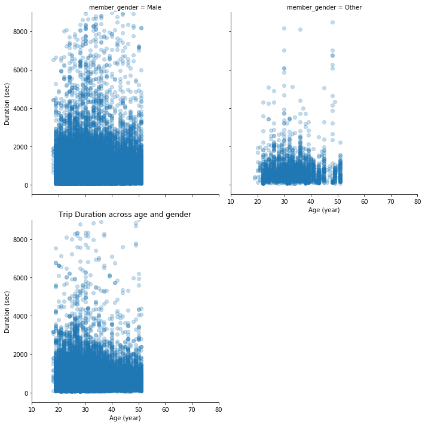

```python
user_types = sb.FacetGrid(data = bike_df, col = 'member_gender', col_wrap = 2, size = 5,
                 xlim = [10, 80], ylim = [-500, 9000])
user_types.map(plt.scatter, 'member_age', 'duration_sec', alpha=0.25)
user_types.set_xlabels('Age (year)')
user_types.set_ylabels('Duration (sec)')
plt.title('Trip Duration across age and gender')

plt.show()
```

### Question 2:How does user type affect trip duration in weekdays?

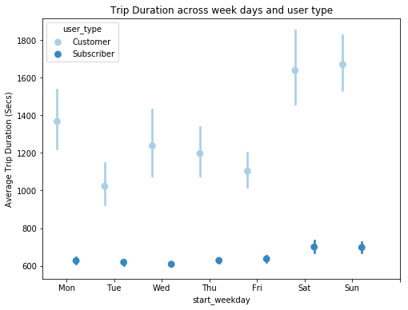

```python
fig = plt.figure(figsize = [8,6])
ax = sb.pointplot(data = bike_df, x ='start_weekday', y = 'duration_sec', hue = 'user_type',
           palette = 'Blues', linestyles = '', dodge = 0.4)
plt.title('Trip Duration across week days and user type')
plt.ylabel('Average Trip Duration (Secs)')
plt.xticks(np.arange(0, 7 + 1, 1),weekday_labels)
ax.set_yticklabels([],minor = True)
plt.show();
```

### Question 3: How does gender affect the trip duration of different type of users?

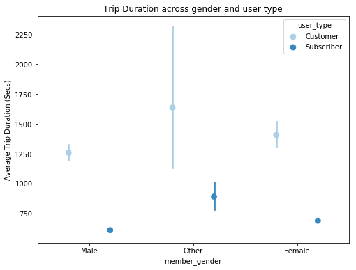

```python
fig = plt.figure(figsize = [8,6])
ax = sb.pointplot(data = bike_df, x ='member_gender', y = 'duration_sec', hue = 'user_type',
           palette = 'Blues', linestyles = '', dodge = 0.4)
plt.title('Trip Duration across gender and user type')
plt.ylabel('Average Trip Duration (Secs)')
ax.set_yticklabels([],minor = True)
plt.show();
```

The other gender take long trips followed by females for all user type.

### Question 4: How does bike sharing and gender affect trip duration?

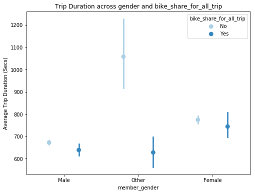

```python
fig = plt.figure(figsize = [8,6])
ax = sb.pointplot(data = bike_df, x ='member_gender', y = 'duration_sec', hue = 'bike_share_for_all_trip',
           palette = 'Blues', linestyles = '', dodge = 0.4)
plt.title('Trip Duration across gender and bike_share_for_all_trip')
plt.ylabel('Average Trip Duration (Secs)')
ax.set_yticklabels([],minor = True)
plt.show();
```